# Loutre_analyse

Pablo

2025-05-06

# 1 Importation des packages

```r
library(tidyverse)
library(gridExtra)
library(lubridate)
library(sf)
library(mapview)
library(maptiles)
library(tidyterra)
library(kableExtra)
library(knitr)
library(RVAideMemoire)
library(emmeans)
library(car)
library(MASS)
library(lme4)
library(MuMIn)
```

# 2 Importation des données - Secteur J25 : Petit Tregor

```r
base_tregor <-
  readxl::read_xlsx(path = '../raw_data/export_suiviloutrelocal_telecharger_csv_2025_04_03_10h58m17.xlsx') %>%
  dplyr::select(
    id_dataset,
    code_secteur,
    code_site,
    nom_site,
    x_l93,
    y_l93,
    date_visite,
    observateurs,
    condition_prospection,
    nom_taxon,
    nom_complet_taxon,
    techn_observation,
    statut_observation,
    nb_ep_tot,
    nb_ep_w,
    nb_ep_dnf,
    nb_ep_df
  ) %>%
  mutate(
    annee = year(date_visite),
    mois = month(date_visite),
    jour = day(date_visite),
    nb_ep_w = abs(nb_ep_w),
    statut_observation = ifelse(str_detect(statut_observation, '^Pr'), yes = 'Présent', no = 'Absent')
  ) %>%
  filter(nom_complet_taxon =='Lutra lutra',
         !(id_dataset == 85 & code_secteur == "FR5300006"),
         code_secteur != "J401")
```

# 3 Représentation cartographique des secteurs d’étude et des sites correspondants

```r
sites_geo <- base_tregor %>%
  dplyr::select(nom_site:y_l93,
         statut_observation,
         code_secteur,
         annee) %>%
  sf::st_as_sf(coords = c("x_l93", "y_l93"),
               crs = sf::st_crs(2154))

mapview::mapview(sites_geo,
                 zcol = "code_secteur",
                 col.regions = c("FR5300006" = "indianred1",
                                 "J25" = "darkseagreen3")
)
```

[interactive chart not shown]

```r
base_j25 <- base_tregor %>%
  filter(code_secteur == "J25") %>%
  mutate(statut_presence = ifelse(as.character(statut_observation) == "Présent", 1, 0))
```

# 4 Analyse statistiques - Modèle Linéaire Généralisé (GLM)

## 4.1 Modèle 1 : Le statut d’observation depend de l’année

### 4.1.1 Construction du modèle

#### 4.1.1.2 **Choix de la distribution de référence**

=> **Distribution Binomiale**

#### 4.1.1.3 **Choix de la fonction de lien**

=> **logit**

```r
mod1 <- glm(statut_presence~annee, family=binomial(link = "logit"), data = base_j25)
```

### 4.1.2 Vérification de l’ajustement du modèle aux données

- **Vérification de la linéarité du modèle**

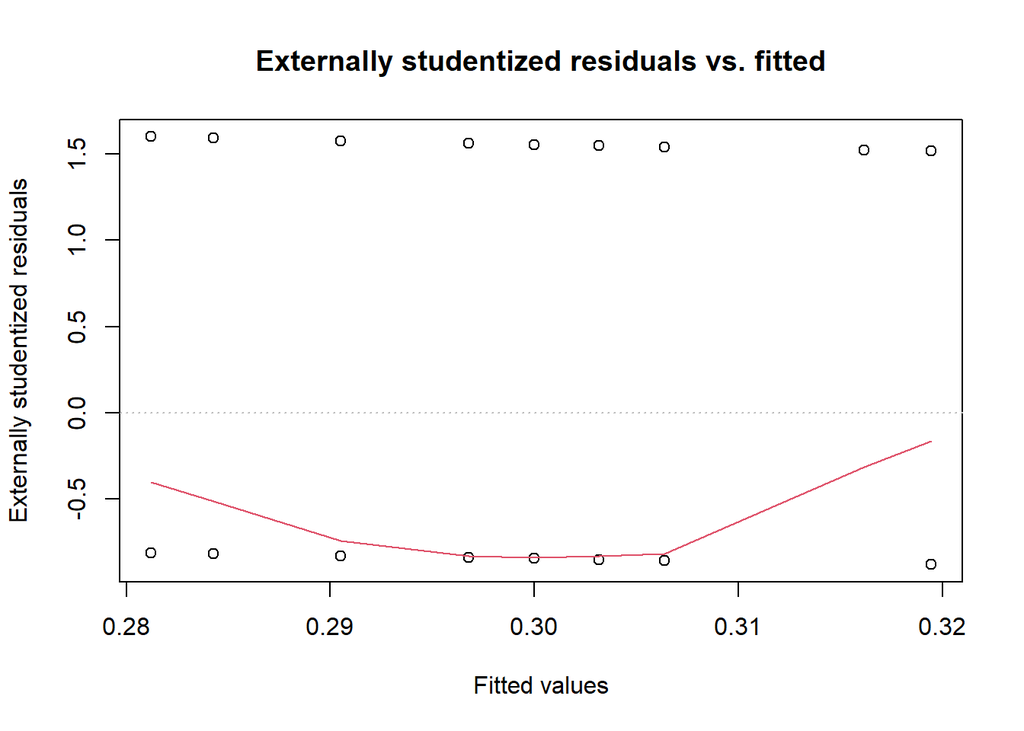

```r
plotresid(mod1)
```

La relation semble linéaire, il n’y a aucune structuration dans les résidus autrement dit indépendance entre les valeurs prédites (𝜇) et les résidus (𝜀)

- **Vérification de la relation entre mu et v**

```r
summary(mod1)
```

```
##
## Call:
## glm(formula = statut_presence ~ annee, family = binomial(link = "logit"),
##     data = base_j25)
##
## Coefficients:
##              Estimate Std. Error z value Pr(>|z|)
## (Intercept) -31.47494   60.70886  -0.518    0.604
## annee         0.01518    0.03010   0.504    0.614
##
## (Dispersion parameter for binomial family taken to be 1)
##
##     Null deviance: 505.46  on 413  degrees of freedom
## Residual deviance: 505.20  on 412  degrees of freedom
## AIC: 509.2
##
## Number of Fisher Scoring iterations: 4
```

```r
heteroscedasticite <- function(deviance_residuelle, dl_residuelle){
  deviance_residuelle /dl_residuelle
}

heteroscedasticite(505.20, 412)
```

```
## [1] 1.226214
```

= > Seuil de 1 (ou 1,5), On observe une légère sur-dispersion des résidus

Problème de surdispersion (hétéroscédasticité différente de l’attendu)

#### 4.1.2.1 **Remplacer la loi binomiale par une loi quasi-binomiale**

```r
mod1.1 <- glm(statut_presence~annee,quasibinomial(link = "logit"), data = base_j25)
```

- **Vérification de la linéarité du modèle**

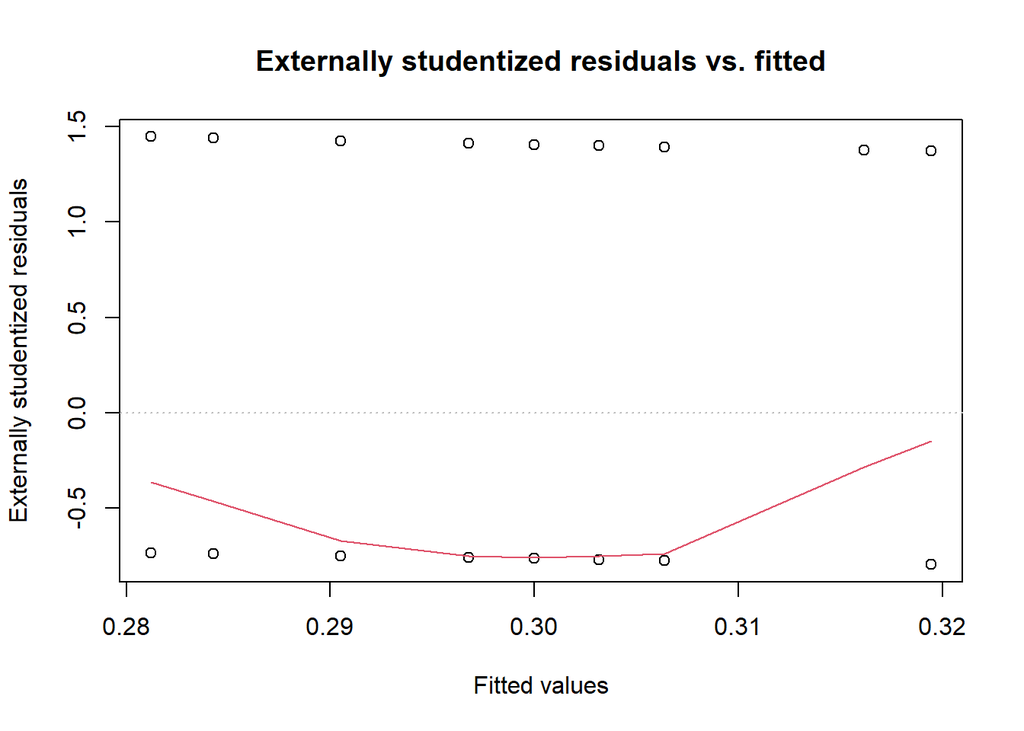

```r
plotresid(mod1.1)
```

La relation semble linéaire, il n’y a aucune structuration dans les résidus autrement dit indépendance entre les valeurs prédites (𝜇) et les résidus (𝜀)

- **Vérification de la relation entre mu et v**

```r
summary(mod1.1)
```

```
##
## Call:
## glm(formula = statut_presence ~ annee, family = quasibinomial(link = "logit"),
##     data = base_j25)
##
## Coefficients:
##              Estimate Std. Error t value Pr(>|t|)
## (Intercept) -31.47494   60.86526  -0.517    0.605
## annee         0.01518    0.03018   0.503    0.615
##
## (Dispersion parameter for quasibinomial family taken to be 1.005159)
##
##     Null deviance: 505.46  on 413  degrees of freedom
## Residual deviance: 505.20  on 412  degrees of freedom
## AIC: NA
##
## Number of Fisher Scoring iterations: 4
```

```r
heteroscedasticite <- function(deviance_residuelle, dl_residuelle){
  deviance_residuelle /dl_residuelle
}

heteroscedasticite(505.20, 412)
```

```
## [1] 1.226214
```

=> Seuil de 1 (ou 1,5), On observe une sur-dispersion des résidus

#### 4.1.2.2 Introduction d’un facteur aléatoiree à 1 modalité / donnée ? GLMM

### 4.1.3 Exploitation du modèle

```r
anova(mod1)
```

```
## Analysis of Deviance Table
##
## Model: binomial, link: logit
##
## Response: statut_presence
##
## Terms added sequentially (first to last)
##
##
##       Df Deviance Resid. Df Resid. Dev Pr(>Chi)
## NULL                    413     505.46
## annee  1  0.25455       412     505.20   0.6139
```

```r
anova(mod1.1)
```

```
## Analysis of Deviance Table
##
## Model: quasibinomial, link: logit
##
## Response: statut_presence
##
## Terms added sequentially (first to last)
##
##
##       Df Deviance Resid. Df Resid. Dev      F Pr(>F)
## NULL                    413     505.46
## annee  1  0.25455       412     505.20 0.2532 0.6151
```

## 4.2 Modèle 2 : Le nombre total de marquage depend de l’année

### 4.2.1 Construction du modèle

#### 4.2.1.2 **Choix de la distribution de référence**

=> **Distribution de Poisson**

#### 4.2.1.3 **Choix de la fonction de lien**

=> **ln**

```r
mod2 <- glm(nb_ep_tot~annee, family=poisson(link = "log"), data = base_j25)
```

### 4.2.2 Vérification de l’ajustement du modèle aux données

- **Vérification de la linéarité du modèle**

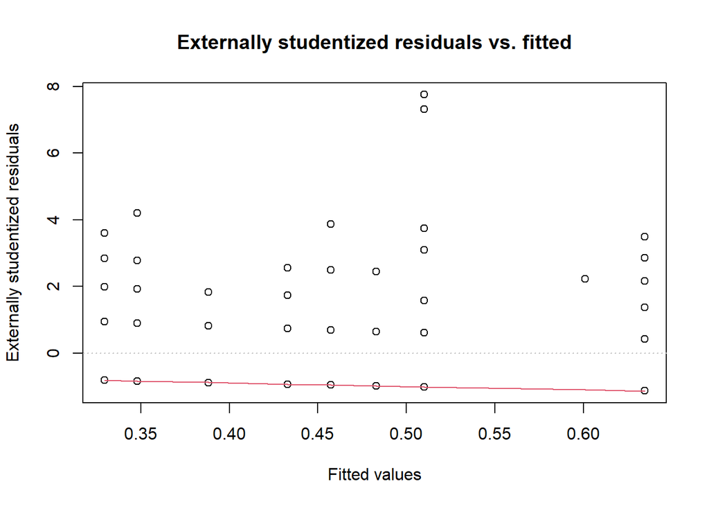

```r
plotresid(mod2)
```

La relation semble linéaire, il n’y a aucune structuration dans les résidus autrement dit indépendance entre les valeurs prédites (𝜇) et les résidus (𝜀) ??

#### 4.2.2.1 **Remplacer la fonction de lien “ln” par “identité”**

```r
mod2.1 <- glm(nb_ep_tot~annee, family=poisson(link = "identity"), data = base_j25)
```

- **Vérification de la linéarité du modèle**

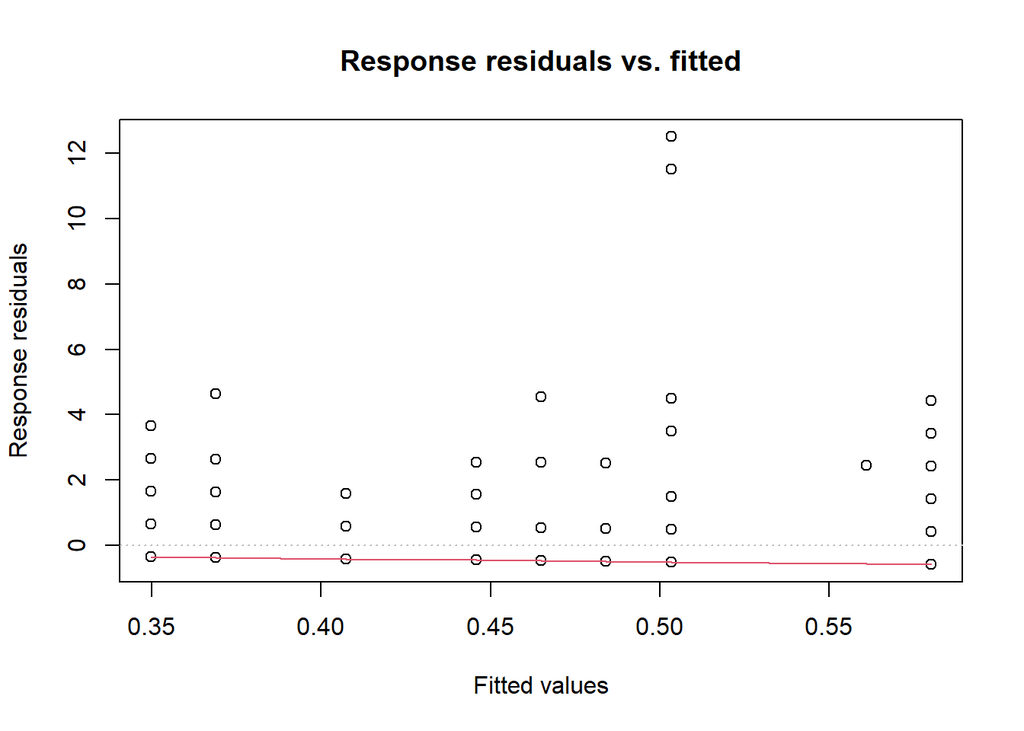

```r
plotresid(mod2.1)
```

La relation semble linéaire, il n’y a aucune structuration dans les résidus autrement dit indépendance entre les valeurs prédites (𝜇) et les résidus (𝜀) ??

Ne change pas grand chose entre mod2 et mod2.1, on conserve mod2

- **Vérification de la relation entre mu et v**

```r
summary(mod2)
```

```
##
## Call:
## glm(formula = nb_ep_tot ~ annee, family = poisson(link = "log"),
##     data = base_j25)
##
## Coefficients:
##               Estimate Std. Error z value Pr(>|z|)
## (Intercept) -110.95261   40.87787  -2.714  0.00664 **
## annee          0.05462    0.02026   2.696  0.00702 **
## ---
## Signif. codes:  0 '***' 0.001 '**' 0.01 '*' 0.05 '.' 0.1 ' ' 1
##
## (Dispersion parameter for poisson family taken to be 1)
##
##     Null deviance: 677.27  on 413  degrees of freedom
## Residual deviance: 669.99  on 412  degrees of freedom
## AIC: 900.13
##
## Number of Fisher Scoring iterations: 6
```

```r
heteroscedasticite <- function(deviance_residuelle, dl_residuelle){
  deviance_residuelle /dl_residuelle
}
heteroscedasticite(669.99, 412)
```

```
## [1] 1.626189
```

=> Supérieur au seuil de 1 (ou 1,5), sur-dispersion des résidus. Problème de surdispersion (hétéroscédasticité différente de l’attendu), la relation entre mu et v n’est pas vérifié.

- **Vérification de la relation entre mu et v**

```r
summary(mod2.1)
```

```
##
## Call:
## glm(formula = nb_ep_tot ~ annee, family = poisson(link = "identity"),
##     data = base_j25)
##
## Coefficients:
##               Estimate Std. Error z value Pr(>|z|)
## (Intercept) -38.249446  18.713188  -2.044   0.0410 *
## annee         0.019194   0.009281   2.068   0.0386 *
## ---
## Signif. codes:  0 '***' 0.001 '**' 0.01 '*' 0.05 '.' 0.1 ' ' 1
##
## (Dispersion parameter for poisson family taken to be 1)
##
##     Null deviance: 677.27  on 413  degrees of freedom
## Residual deviance: 671.67  on 412  degrees of freedom
## AIC: 901.8
##
## Number of Fisher Scoring iterations: 8
```

```r
heteroscedasticite <- function(deviance_residuelle, dl_residuelle){
  deviance_residuelle /dl_residuelle
}
heteroscedasticite(671.67, 412)
```

```
## [1] 1.630267
```

=> La modification de la fonction de lien rend la surdispersion des résidus plus importante, on conserve donc le modèle 2

#### 4.2.2.2 **Remplacer la loi de Poisson par une loi binomiale négative**

```r
mod2.2 <- MASS::glm.nb(nb_ep_tot~annee, link = log, data = base_j25)
```

- **Vérification de la linéarité du modèle**

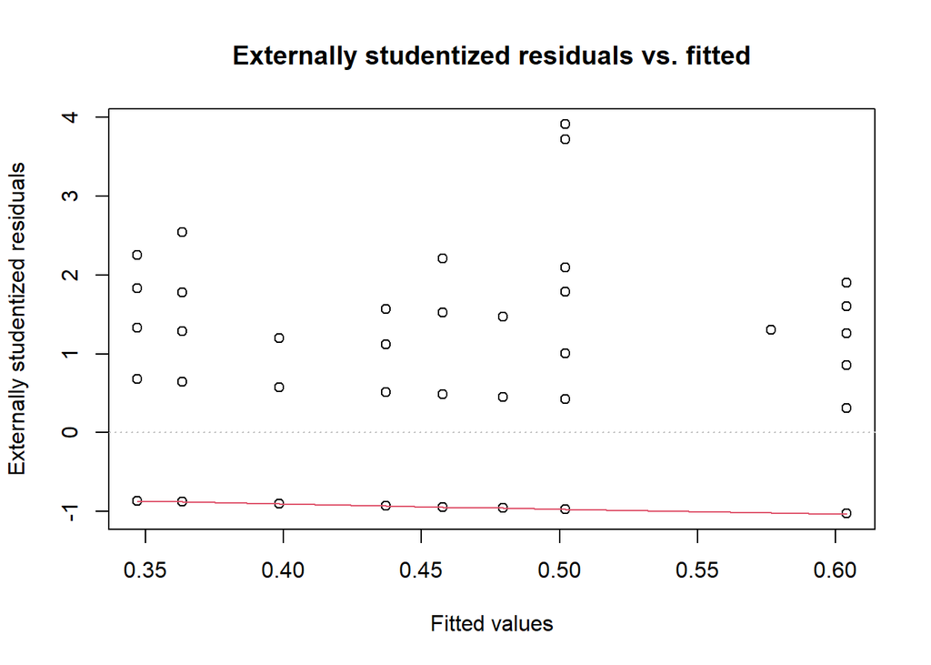

```r
plotresid(mod2.2)
```

- **Vérification de la relation entre mu et v**

```r
summary(mod2.2)
```

```
##
## Call:
## MASS::glm.nb(formula = nb_ep_tot ~ annee, data = base_j25, link = log,
##     init.theta = 0.231506119)
##
## Coefficients:
##              Estimate Std. Error z value Pr(>|z|)
## (Intercept) -93.87667   71.10228  -1.320    0.187
## annee         0.04616    0.03525   1.309    0.190
##
## (Dispersion parameter for Negative Binomial(0.2315) family taken to be 1)
##
##     Null deviance: 235.75  on 413  degrees of freedom
## Residual deviance: 233.70  on 412  degrees of freedom
## AIC: 704.94
##
## Number of Fisher Scoring iterations: 1
##
##
##               Theta:  0.2315
##           Std. Err.:  0.0419
##
##  2 x log-likelihood:  -698.9420
```

```r
heteroscedasticite <- function(deviance_residuelle, dl_residuelle){
  deviance_residuelle /dl_residuelle
}
heteroscedasticite(233.70, 412)
```

```
## [1] 0.567233
```

=> Supérieur au seuil de 0,5 (on est en dessous du seuil de 1), sousdispersion des résidus

### 4.2.3 Exploitation du modèle

```r
Anova (mod2)
```

```
## Analysis of Deviance Table (Type II tests)
##
## Response: nb_ep_tot
##       LR Chisq Df Pr(>Chisq)
## annee   7.2725  1   0.007002 **
## ---
## Signif. codes:  0 '***' 0.001 '**' 0.01 '*' 0.05 '.' 0.1 ' ' 1
```

```r
Anova (mod2.2)
```

```
## Analysis of Deviance Table (Type II tests)
##
## Response: nb_ep_tot
##       LR Chisq Df Pr(>Chisq)
## annee   2.0488  1     0.1523
```

## 4.3 Modèle 3 : Le statut d’observation depend de l’année

### 4.3.1 Construction du modèle

#### 4.3.1.1 **Definition des types de variables**

- **Variable réponse** : Statut_présence, variable qualitative binaire, nominale
- **Variable explicative** :
- Annee, variable qualitative ordinale
- Site, variable qualitative ordinale

#### 4.3.1.2 **Choix de la distribution de référence**

=> **Distribution Binomiale**

#### 4.3.1.3 **Choix de la fonction de lien**

=> **logit**

#### 4.3.1.4 **Modèle mixte**

```r
mod3 <- glmer(statut_presence~annee+(1|code_site), family=binomial(link = "logit"), data = base_j25)
```

### 4.3.2 Vérification de l’ajustement du modèle aux données

- **Vérification de la linéarité du modèle**

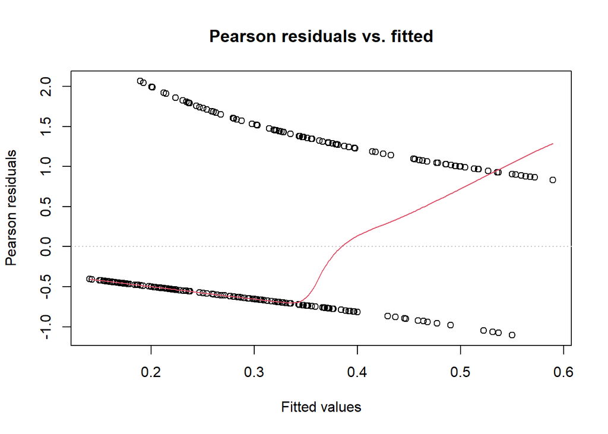

```r
plotresid(mod3)
```

La relation ne semble pas linéaire, il y a une structuration dans les résidus autrement dit dépendance entre les valeurs prédites (𝜇) et les résidus (𝜀).

#### 4.3.2.1 **Remplacer la fonction de lien “logit” par “probit”**

```r
mod3.1 <- glmer(statut_presence~annee+(1|code_site), family=binomial(link = "probit"), data = base_j25)
```

**Vérification de l’indépendance des résidus**

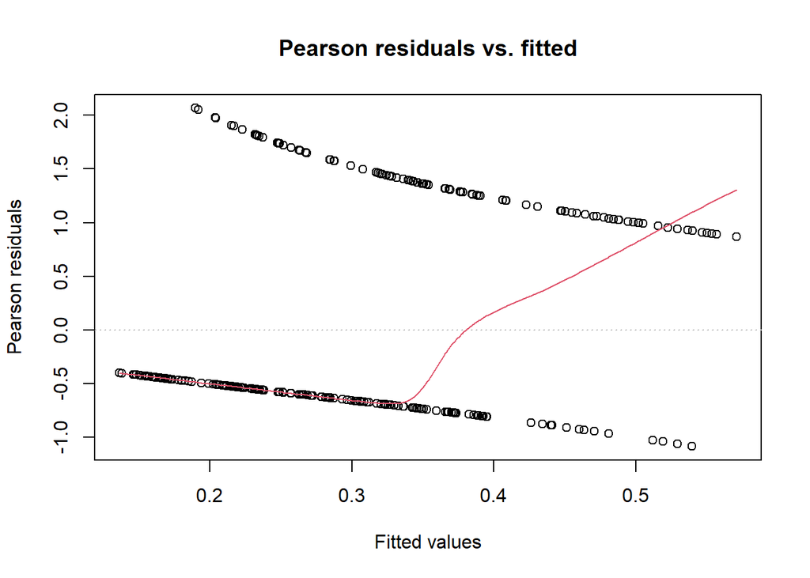

```r
plotresid(mod3.1)
```

La relation ne semble pas linéaire, il y a une structuration dans les résidus autrement dit dépendance entre les valeurs prédites (𝜇) et les résidus (𝜀).

#### 4.3.2.2 **Remplacer la fonction de lien “logit” par “cauchit”**

```r
mod3.2 <- glmer(statut_presence~annee+(1|code_site), family=binomial(link = "cauchit"), data = base_j25)
```

**Vérification de l’indépendance des résidus**

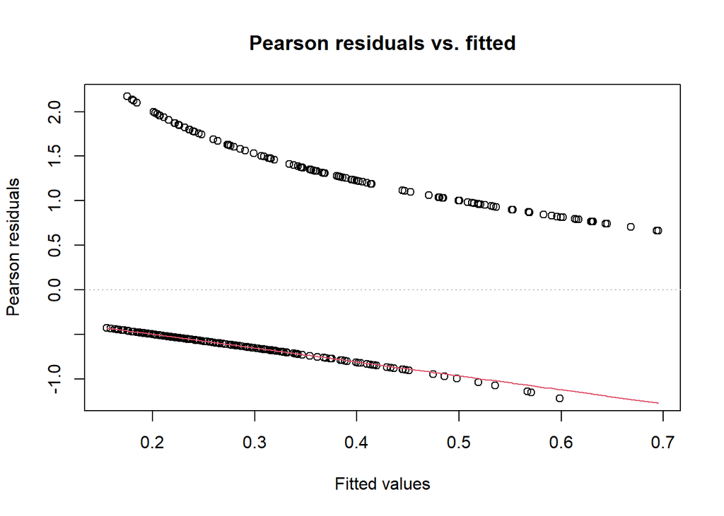

```r
plotresid(mod3.2)
```

La relation semble linéaire, il n’y a pas une structuration dans les résidus autrement dit indépendance entre les valeurs prédites (𝜇) et les résidus (𝜀).

### 4.3.3 Capacité explicative globale

**Valeur des coefficients (estimate)**

```r
summary(mod3.2)
```

```
## Generalized linear mixed model fit by maximum likelihood (Laplace
##   Approximation) [glmerMod]
##  Family: binomial  ( cauchit )
## Formula: statut_presence ~ annee + (1 | code_site)
##    Data: base_j25
##
##      AIC      BIC   logLik deviance df.resid
##    497.5    509.6   -245.8    491.5      411
##
## Scaled residuals:
##     Min      1Q  Median      3Q     Max
## -1.2206 -0.6018 -0.5114  0.8926  2.1698
##
## Random effects:
##  Groups    Name        Variance Std.Dev.
##  code_site (Intercept) 0.673    0.8204
## Number of obs: 414, groups:  code_site, 60
##
## Fixed effects:
##               Estimate Std. Error  z value Pr(>|z|)
## (Intercept) -1.080e+02  1.976e-03 -54647.9   <2e-16 ***
## annee        5.306e-02  7.847e-05    676.2   <2e-16 ***
## ---
## Signif. codes:  0 '***' 0.001 '**' 0.01 '*' 0.05 '.' 0.1 ' ' 1
##
## Correlation of Fixed Effects:
##       (Intr)
## annee -0.012
## optimizer (Nelder_Mead) convergence code: 0 (OK)
## Model failed to converge with max|grad| = 0.0464875 (tol = 0.002, component 1)
## Model is nearly unidentifiable: very large eigenvalue
##  - Rescale variables?
```

### 4.3.4 Exploitation du modèle

#### 4.3.4.1 **Test de Wald**

```r
Anova(mod3.2)
```

```
## Analysis of Deviance Table (Type II Wald chisquare tests)
##
## Response: statut_presence
##        Chisq Df Pr(>Chisq)
## annee 457263  1  < 2.2e-16 ***
## ---
## Signif. codes:  0 '***' 0.001 '**' 0.01 '*' 0.05 '.' 0.1 ' ' 1
```

#### 4.3.4.2 **Comparaisons multiples**

Remarque : PAS OUBLIER DE REVENIR à la REPONSE